# PreformanceEvaluation

```r
control1 = trainControl(method="repeatedcv", number=10, repeats=2)
control = trainControl(method="adaptive_cv", number=10, repeats=2)
metric = "Accuracy"
```

```r
# Predicting Age/Ring/Year(ring + 1.5)
fit.knn = train(year~., data = ab, method= "knn",  preProcess="scale",trCrontrol = control)
fit.rf = train(year~., data=ab, method="rf", preProcess="scale", trCrontrol = control)
#fit.svm = train(year~., data=ab, method="svmRadial", preProcess="scale", trControl=control1)
#fit.cart = train(year~., data=ab, method="rpart", preProcess="scale", trControl=control1)
```

```r
#results = caret::resamples(list(KNN=fit.knn, RF=fit.rf, SVM=fit.svm, cart=fit.cart))
results = caret::resamples(list(KNN=fit.knn, RF=fit.rf))
```

```r
summary(results)
```

```
##
## Call:
## summary.resamples(object = results)
##
## Models: KNN, RF
## Number of resamples: 25
##
## MAE
##         Min.  1st Qu.   Median     Mean  3rd Qu.     Max. NA's
## KNN 1.559762 1.592040 1.618041 1.618385 1.644956 1.661064    0
## RF  1.454464 1.492506 1.513391 1.510739 1.531085 1.563526    0
##
## RMSE
##         Min.  1st Qu.   Median     Mean  3rd Qu.     Max. NA's
## KNN 2.217119 2.285253 2.311788 2.313478 2.339342 2.418135    0
## RF  2.026138 2.088996 2.130798 2.132629 2.168532 2.242368    0
##
## Rsquared
##          Min.   1st Qu.    Median      Mean   3rd Qu.      Max. NA's
## KNN 0.4594631 0.4790980 0.4918356 0.4915508 0.5013470 0.5309702    0
## RF  0.5410140 0.5549706 0.5667513 0.5637999 0.5721802 0.5865815    0
```

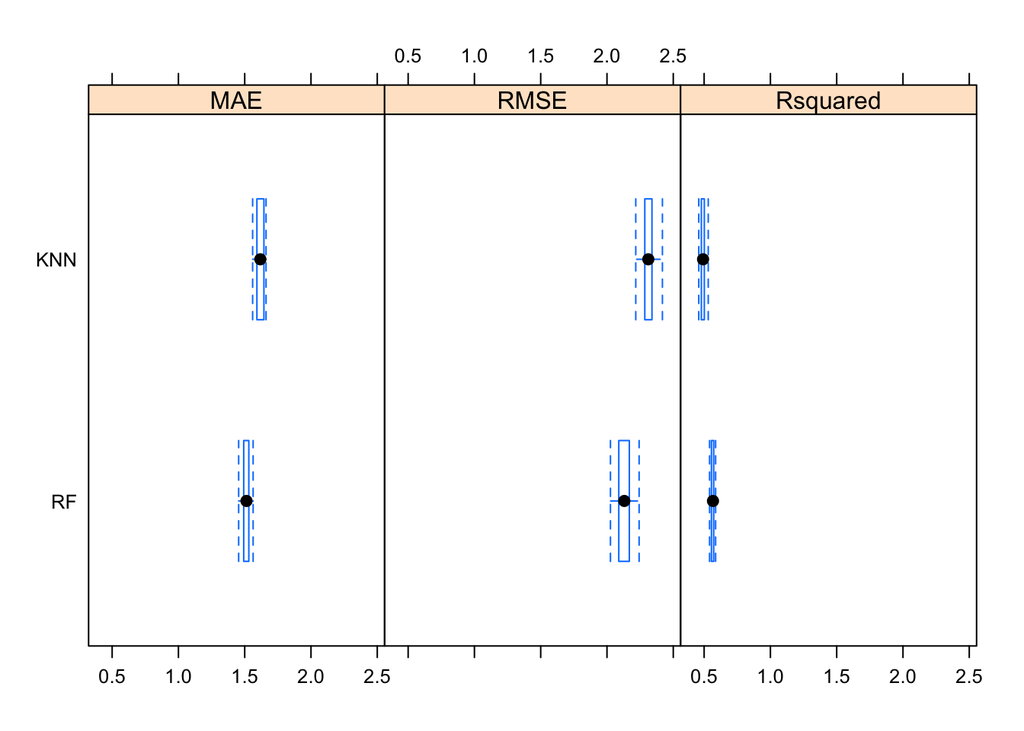

```r
# boxplot comparison
bwplot(results)
```

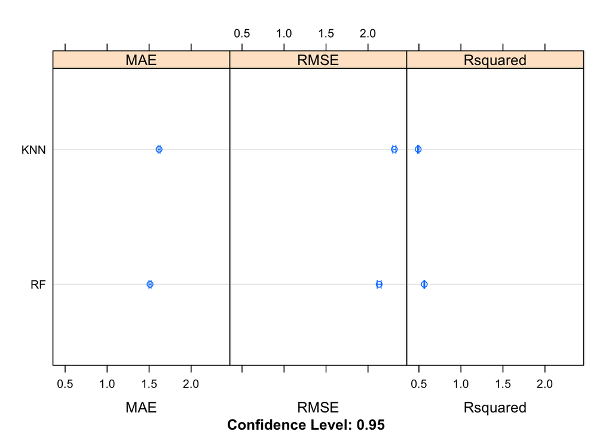

```r
# Dot-plot comparison
dotplot(results)
```

```r
summary(results)
```

```
##
## Call:
## summary.resamples(object = results)
##
## Models: KNN, RF
## Number of resamples: 25
##
## MAE
##         Min.  1st Qu.   Median     Mean  3rd Qu.     Max. NA's
## KNN 1.559762 1.592040 1.618041 1.618385 1.644956 1.661064    0
## RF  1.454464 1.492506 1.513391 1.510739 1.531085 1.563526    0
##
## RMSE
##         Min.  1st Qu.   Median     Mean  3rd Qu.     Max. NA's
## KNN 2.217119 2.285253 2.311788 2.313478 2.339342 2.418135    0
## RF  2.026138 2.088996 2.130798 2.132629 2.168532 2.242368    0
##
## Rsquared
##          Min.   1st Qu.    Median      Mean   3rd Qu.      Max. NA's
## KNN 0.4594631 0.4790980 0.4918356 0.4915508 0.5013470 0.5309702    0
## RF  0.5410140 0.5549706 0.5667513 0.5637999 0.5721802 0.5865815    0
```

Test Metric Some good test metrics to use for different problem types include:

Classification:

- Accuracy: x correct divided by y total instances. Easy to understand and widely used.
- Kappa: easily understood as accuracy that takes the base distribution of classes into account.

# Regression:

- RMSE: root mean squared error. Again, easy to understand and widely used.
- Rsquared: the goodness of fit or coefficient of determination.

ROC and LogLoss are other popular measures.

```r
#Predicting Sex
fit.knn2 = train(sex~., data=ab, method="knn", preProcess="scale", trControl=control1)
fit.rpart2 = train(sex~., data=ab, method="rpart", preProcess="scale", trControl=control1)
# Take a lot of computing power to finish but ends up as #2
#fit.rf2 = train(sex~., data=ab, method="rf", preProcess="scale", trControl=control1)
fit.svm2 = train(sex~., data=ab, method="svmRadial", preProcess="scale", trControl=control1)
fit.cart2 = train(sex~., data=ab, method="rpart", preProcess="scale", trControl=control1)
```

```r
#results2 = resamples(list(knn=fit.knn2, rpart=fit.rpart2, rf=fit.rf2, svm=fit.svm2, cart=fit.cart2))
results2 = resamples(list(knn=fit.knn2, rpart=fit.rpart2, svm=fit.svm2, cart=fit.cart2))
```

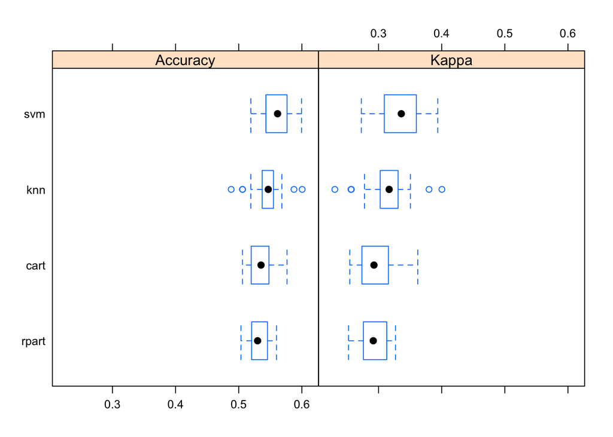

```r
bwplot(results2)
```

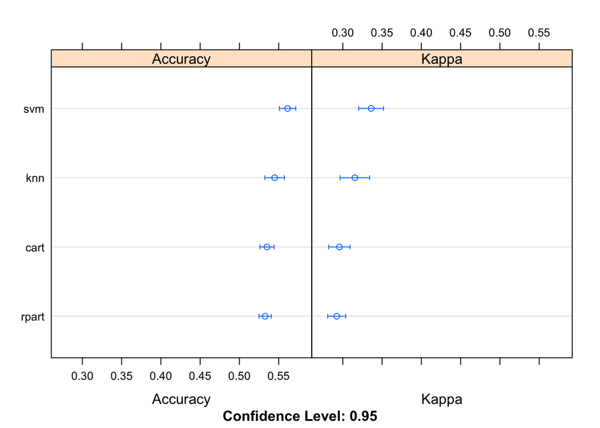

```r
dotplot(results2)
```

```r
summary(results2)
```

```
##
## Call:
## summary.resamples(object = results2)
##
## Models: knn, rpart, svm, cart
## Number of resamples: 20
##
## Accuracy
##            Min.   1st Qu.    Median      Mean   3rd Qu.      Max. NA's
## knn   0.4880383 0.5376794 0.5467626 0.5447667 0.5550239 0.6004785    0
## rpart 0.5035800 0.5203837 0.5299043 0.5326854 0.5443159 0.5598086    0
## svm   0.5192308 0.5430622 0.5615244 0.5612802 0.5765550 0.5995204    0
## cart  0.5059666 0.5199995 0.5353258 0.5350688 0.5466507 0.5765550    0
##
## Kappa
##            Min.   1st Qu.    Median      Mean   3rd Qu.      Max. NA's
## knn   0.2307520 0.3028034 0.3167750 0.3153336 0.3306923 0.4002869    0
## rpart 0.2524532 0.2767583 0.2916367 0.2922189 0.3121964 0.3268346    0
## svm   0.2727527 0.3094666 0.3360007 0.3360367 0.3593166 0.3937898    0
## cart  0.2543612 0.2750586 0.2927133 0.2956693 0.3143061 0.3620522    0
```